# Predicting Student Success Using Behavioral and Academic Factors

[figure not shown]

Source of Image from: https://www.uopeople.edu/blog/importance-of-social-emotional-learning/

## Spring 2025 Data Science Project

**Contributors:** Fereshta Mohammadi, Fakhreya Mohammadi

### Contributions

- **Fereshta Mohammadi**
  - **A. Project Idea:** Proposed the initial project idea and objective.
  - **B. Dataset Curation and Preprocessing:** Handled missing values and outliers.
  - **C. Data Exploration:** Created summary statistics and boxplots to detect and handle outliers.
  - **D. ML Algorithm Design:** Implemented IQR method to handle outliers.
  - **G. Final Report Creation:** Structured the notebook and added markdown explanations. .
- **Fakhreya Mohammadi**
  - **A. Project Idea:** Helped refine the project idea.
  - **C. Data Exploration:** Created visualizations and interpreted patterns.
  - **E. ML Training and Testing:** Evaluated models and analyzed performance.
  - **F. Visualization & Conclusion:** Wrote the final analysis and insights.

## **Introduction**

Achieving success in college is a crucial goal for students since it has a big impact on their future career opportunities and personal growth. The measurement of a student's success or performance is affected by the interaction of numerous factors and variables. Since there is a wide range of factors, it is very challenging to fully account for all the factors to measure a student's performance. However, some key behavioral and academic factors can help to analyze a student's performance and predict student outcomes based on them. This project investigates the factors such as study hours, attendance, access to resources, extracurricular activities, sleep hours, motivation level, and family income affecting student performance using machine learning and statistical analysis. Our project focuses on exploring what affects academic success among students.

This project aims to address the following questions:

- What key behavioral and academic factors most significantly influence student academic performance?
- Can we predict student success academically using available features?

## **Data Curation**

### Data Source

The dataset used in this project is sourced from “Kaggle”.

Link Address: [Factors_Affecting_Student_Performance](https://www.kaggle.com/datasets/lainguyn123/student-performance-factors)

It contains information on students’ academic behaviors and outcomes, including features like Hours_Studied, Attendance, Parental_Involvement, Access_to_Resources, Extracurricular_Activities, Sleep_Hours, Previous_Scores, Motivation_Level, Internet_Access, Tutoring_Sessions, Family_Income , Teacher_Quality, School_Type, Peer_Influence, Physical_Activity, Learning_Disabilities, Parental_Education_Level, Distance_from_Home, Gender, and Exam_Score.

This dataset represents various factors that may influence student performance, including numeric and categorical data.

```python
# importing the required libraries, run it once
import pandas as pd
import scipy.stats as stats
import matplotlib.pyplot as plt
from scipy.stats import ttest_ind
from sklearn.model_selection import train_test_split
from sklearn.linear_model import LinearRegression
from sklearn.metrics import mean_squared_error, r2_score
from sklearn.preprocessing import StandardScaler
import seaborn as sns
from scipy.stats import f_oneway
from scipy.stats import pearsonr
```

```python
# importing the data as a datafram assgining it to df variable
df = pd.read_csv('StudentPerformanceFactors.csv')

#displaying the dataset
df
```

|  | Hours_Studied | Attendance | Parental_Involvement | Access_to_Resources | Extracurricular_Activities | Sleep_Hours | Previous_Scores | Motivation_Level | Internet_Access | Tutoring_Sessions | Family_Income | Teacher_Quality | School_Type | Peer_Influence | Physical_Activity | Learning_Disabilities | Parental_Education_Level | Distance_from_Home | Gender | Exam_Score |
| --- | --- | --- | --- | --- | --- | --- | --- | --- | --- | --- | --- | --- | --- | --- | --- | --- | --- | --- | --- | --- |
| 0 | 23 | 84 | Low | High | No | 7 | 73 | Low | Yes | 0 | Low | Medium | Public | Positive | 3 | No | High School | Near | Male | 67 |
| 1 | 19 | 64 | Low | Medium | No | 8 | 59 | Low | Yes | 2 | Medium | Medium | Public | Negative | 4 | No | College | Moderate | Female | 61 |
| 2 | 24 | 98 | Medium | Medium | Yes | 7 | 91 | Medium | Yes | 2 | Medium | Medium | Public | Neutral | 4 | No | Postgraduate | Near | Male | 74 |
| 3 | 29 | 89 | Low | Medium | Yes | 8 | 98 | Medium | Yes | 1 | Medium | Medium | Public | Negative | 4 | No | High School | Moderate | Male | 71 |
| 4 | 19 | 92 | Medium | Medium | Yes | 6 | 65 | Medium | Yes | 3 | Medium | High | Public | Neutral | 4 | No | College | Near | Female | 70 |
| ... | ... | ... | ... | ... | ... | ... | ... | ... | ... | ... | ... | ... | ... | ... | ... | ... | ... | ... | ... | ... |
| 6602 | 25 | 69 | High | Medium | No | 7 | 76 | Medium | Yes | 1 | High | Medium | Public | Positive | 2 | No | High School | Near | Female | 68 |
| 6603 | 23 | 76 | High | Medium | No | 8 | 81 | Medium | Yes | 3 | Low | High | Public | Positive | 2 | No | High School | Near | Female | 69 |
| 6604 | 20 | 90 | Medium | Low | Yes | 6 | 65 | Low | Yes | 3 | Low | Medium | Public | Negative | 2 | No | Postgraduate | Near | Female | 68 |
| 6605 | 10 | 86 | High | High | Yes | 6 | 91 | High | Yes | 2 | Low | Medium | Private | Positive | 3 | No | High School | Far | Female | 68 |
| 6606 | 15 | 67 | Medium | Low | Yes | 9 | 94 | Medium | Yes | 0 | Medium | Medium | Public | Positive | 4 | No | Postgraduate | Near | Male | 64 |

6607 rows × 20 columns

### Feature Selection

```python
# showing number of columns and rows
df.shape
```

```
(6607, 20)
```

Number of data points: 6607

The data set contains 6607 data points, and each data point represents a student in our dataset. We have a large number of data points which increases the statistical power of our analysis and makes our machine learning model more robust and reliable.

Number of features: 20

Our dataset contains 20 features which shows the amount of information collected for each data point in our dataset. Although more features provide deeper insights about our data, irrelevant or noisy features can also hurt our model performance and statistical analysis. For this reason, we have to implement feature selection.

```python
# displaying the columns (features) of dataset
df.columns
```

```
Index(['Hours_Studied', 'Attendance', 'Parental_Involvement',
       'Access_to_Resources', 'Extracurricular_Activities', 'Sleep_Hours',
       'Previous_Scores', 'Motivation_Level', 'Internet_Access',
       'Tutoring_Sessions', 'Family_Income', 'Teacher_Quality', 'School_Type',
       'Peer_Influence', 'Physical_Activity', 'Learning_Disabilities',
       'Parental_Education_Level', 'Distance_from_Home', 'Gender',
       'Exam_Score'],
      dtype='object')
```

```python
# examining the number of unique variables in data set
df.nunique()
```

```
Hours_Studied                 41
Attendance                    41
Parental_Involvement           3
Access_to_Resources            3
Extracurricular_Activities     2
Sleep_Hours                    7
Previous_Scores               51
Motivation_Level               3
Internet_Access                2
Tutoring_Sessions              9
Family_Income                  3
Teacher_Quality                3
School_Type                    2
Peer_Influence                 3
Physical_Activity              7
Learning_Disabilities          2
Parental_Education_Level       3
Distance_from_Home             3
Gender                         2
Exam_Score                    45
dtype: int64
```

```python
# excluding the not important or unrelated features
df = df.drop(['Parental_Involvement', 'Internet_Access', 'Teacher_Quality', 'Peer_Influence', 'Physical_Activity', 'Learning_Disabilities', 'Distance_from_Home', 'Gender', 'Parental_Education_Level'], axis=1)
```

Based on the result of df.nunique(), the following features have very low variability:

- Parental_Involvement (3 values)
- Internet_Access (2 values)
- Teacher_Quality (3 values)
- Peer_Influence (3 values)
- Physical_Activity (7 values)
- Learning_Disabilities (2 values)
- Distance_from_Home (3 values)
- Gender (2 values)
- Parental_Education_Level (3 values)

Dropping these features are significant for two reasons:

- These features are categorical and binary features in our dataset. They have very limited variation which can make them less useful for building a strong predictive model.
- In addition some of these features like Gender, Internet_Access, and Learning_Disabilities might not show a statistically significant correlation with Exam_Score in our exploratory analysis.

Therefore, dropping them simplifies the model and reduces the risk of overfitting due to noise or irrelavent variables.

### Data Transformation

```python
# examining the types of different features of dataset
df.dtypes
```

```
Hours_Studied                  int64
Attendance                     int64
Access_to_Resources           object
Extracurricular_Activities    object
Sleep_Hours                    int64
Previous_Scores                int64
Motivation_Level              object
Tutoring_Sessions              int64
Family_Income                 object
School_Type                   object
Exam_Score                     int64
dtype: object
```

```python
# chaning the int type to float for better computation of mean variance
for column in df.columns:
    if df[column].dtype == 'int64':
        df[column] = df[column].astype(float)
```

```python
# checking the transformed data types
df.dtypes
```

```
Hours_Studied                 float64
Attendance                    float64
Access_to_Resources            object
Extracurricular_Activities     object
Sleep_Hours                   float64
Previous_Scores               float64
Motivation_Level               object
Tutoring_Sessions             float64
Family_Income                  object
School_Type                    object
Exam_Score                    float64
dtype: object
```

In order to prepare our data for analysis and machine learning model, we converted our numeric columns to float types. This is because float data types is more effective in tasks such as regression as our target variable, Exam_Score, is a continous variable.

### Detecting and Handling Outliers

```python
# getting a general description of data
print(df.describe())
```

```
       Hours_Studied   Attendance  Sleep_Hours  Previous_Scores  \
count    6607.000000  6607.000000   6607.00000      6607.000000
mean       19.975329    79.977448      7.02906        75.070531
std         5.990594    11.547475      1.46812        14.399784
min         1.000000    60.000000      4.00000        50.000000
25%        16.000000    70.000000      6.00000        63.000000
50%        20.000000    80.000000      7.00000        75.000000
75%        24.000000    90.000000      8.00000        88.000000
max        44.000000   100.000000     10.00000       100.000000

       Tutoring_Sessions   Exam_Score
count        6607.000000  6607.000000
mean            1.493719    67.235659
std             1.230570     3.890456
min             0.000000    55.000000
25%             1.000000    65.000000
50%             1.000000    67.000000
75%             2.000000    69.000000
max             8.000000   101.000000
```

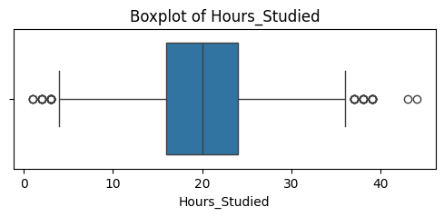

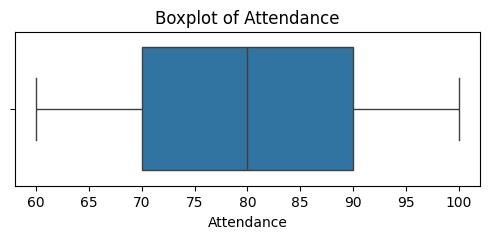

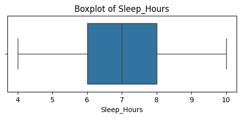

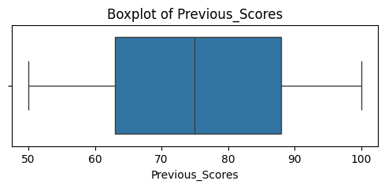

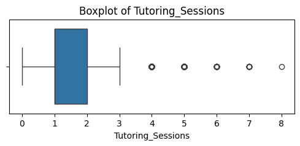

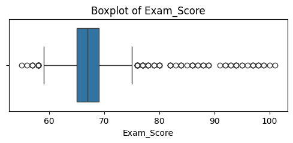

```python
# plotting the numeric columns to see data distribtion and possibly any outliers
numeric_columns = df.select_dtypes(include=['float64']).columns
for col in numeric_columns:
    plt.figure(figsize=(6, 2))
    sns.boxplot(x=df[col])
    plt.title(f'Boxplot of {col}')
    plt.show()
```

We used box plots to detect outliers in our numeric columns visually. As can be observed, there are multiple outliers in several numeric columns in our dataset, like Hours_Studies, Tutoring_Sessions, and Exam_Score. These outliers can skew the analysis and affect the performance of machine learning models.

In the next step, we will handle them appropriately using IQR technique.

```python
# function to detect outliers in a given data frame with given column
def detect_outliers(df, column):

    # using the .quantile, IQR, lower and upper bounds to assess the outlier possibility
    Q1 = df[column].quantile(0.25)
    Q3 = df[column].quantile(0.75)
    IQR = Q3 - Q1
    lower_bound = Q1 - 1.5 * IQR
    upper_bound = Q3 + 1.5 * IQR

    outliers = df[(df[column] < lower_bound) | (df[column] > upper_bound)]
    return outliers, lower_bound, upper_bound

# for each numeric column apply the above function
for numeric_column in numeric_columns:
    outliers, lower_bound, upper_bound = detect_outliers(df, numeric_column)

    median_value = df[numeric_column].median()
    df[numeric_column] = df[numeric_column].apply(lambda x: median_value if x < lower_bound or x > upper_bound else x)

display(df)
```

|  | Hours_Studied | Attendance | Access_to_Resources | Extracurricular_Activities | Sleep_Hours | Previous_Scores | Motivation_Level | Tutoring_Sessions | Family_Income | School_Type | Exam_Score |
| --- | --- | --- | --- | --- | --- | --- | --- | --- | --- | --- | --- |
| 0 | 23.0 | 84.0 | High | No | 7.0 | 73.0 | Low | 0.0 | Low | Public | 67.0 |
| 1 | 19.0 | 64.0 | Medium | No | 8.0 | 59.0 | Low | 2.0 | Medium | Public | 61.0 |
| 2 | 24.0 | 98.0 | Medium | Yes | 7.0 | 91.0 | Medium | 2.0 | Medium | Public | 74.0 |
| 3 | 29.0 | 89.0 | Medium | Yes | 8.0 | 98.0 | Medium | 1.0 | Medium | Public | 71.0 |
| 4 | 19.0 | 92.0 | Medium | Yes | 6.0 | 65.0 | Medium | 3.0 | Medium | Public | 70.0 |
| ... | ... | ... | ... | ... | ... | ... | ... | ... | ... | ... | ... |
| 6602 | 25.0 | 69.0 | Medium | No | 7.0 | 76.0 | Medium | 1.0 | High | Public | 68.0 |
| 6603 | 23.0 | 76.0 | Medium | No | 8.0 | 81.0 | Medium | 3.0 | Low | Public | 69.0 |
| 6604 | 20.0 | 90.0 | Low | Yes | 6.0 | 65.0 | Low | 3.0 | Low | Public | 68.0 |
| 6605 | 10.0 | 86.0 | High | Yes | 6.0 | 91.0 | High | 2.0 | Low | Private | 68.0 |
| 6606 | 15.0 | 67.0 | Low | Yes | 9.0 | 94.0 | Medium | 0.0 | Medium | Public | 64.0 |

6607 rows × 11 columns

The Interquartile Range or IQR technique helps us to identify and handle outliers, data points that significantly deviate from the majority of the data in a dataset. To mark the area or range where most of our data falls, we use the 25th percentile (Q1) and the 75th percentile (Q3)of the data. By calculating the difference between Q3 and Q1, we get a sense of how spread out this middle portion is. To identify outliers, we extend this range by multiplying the IQR by 1.5. Any data point that falls below Q1-1.5 × IQR or above Q3 + 1.5 × IQR is considered an outlier because it lies unusually far from the center of the data. Then we replaced the detected outlier values with the median of the column.

### Handling Missing Values

```python
# examining if there is any missing data in any column
info = df.count()
display(info)
```

```
Hours_Studied                 6607
Attendance                    6607
Access_to_Resources           6607
Extracurricular_Activities    6607
Sleep_Hours                   6607
Previous_Scores               6607
Motivation_Level              6607
Tutoring_Sessions             6607
Family_Income                 6607
School_Type                   6607
Exam_Score                    6607
dtype: int64
```

```python
# checkin is there any mising value in any column
print(df.isnull().sum())
```

```
Hours_Studied                 0
Attendance                    0
Access_to_Resources           0
Extracurricular_Activities    0
Sleep_Hours                   0
Previous_Scores               0
Motivation_Level              0
Tutoring_Sessions             0
Family_Income                 0
School_Type                   0
Exam_Score                    0
dtype: int64
```

Before proceeding with data analsis, we checked the dataset for any missing values using methods like `.isnull().sum()`. The results we found show that there are no missing values in any of the columns. This ensures that our dataset is complete and does not require any imputation or removal of rows due to missing data.

## **Exploratory data analysis**

### Relationship between Academic Factors and Student Performance

The academic factors present in our dataset are Hours_Studied, Attendance, Access_to_Resources, Tutoring_Sessions, and Previous_Scores. For our first step, we will examine the relationship between our target variable, which is Exam_Score and academic factors. These academic factors provide useful information regarding a student's prior academic achievement and learning opportunities. For example,

- Hours_Studied: This factor in our dataset shows the amount of time a student invests to study outside of the regular class.
- Attendance: The percentage of a student's attendance in class reflects the participation level of a student in class. This is important as it affects a student's understanding of materials.
- Access_to_Resources: Access to resources such as the internet, textbooks, and other useful materials impacts a student's performance as he/she can easily learn and understand unlearned content.
- Tutoring_Sessions: Provide extra academic support for students, which helps to fill gaps in understanding of materials.
- Previous_Scores: Is an important factor since it shows a student's previous knowledge and examination of a student's performance over time.

Finally, our main goal is to to determine if there is a significant correlation between Exam_Score and various academic factors by using the proper statistical tests.

**Hypothesis Test 1: Hours_Studied vs. Exam_Score**

Hours_studied represents the number of hours a student spent studying per week. Exam_Score is the final exam score. We aim to use the pearson correlation test to see whether they have any relationship. To use that test, we must assume that the data is normally distributed and that they have linear relationship. To check this we plot the graph below and anaylize the linearlty of the relatiohsip. Additionally, we state the null and alternative hypothesis as follow:

Null Hypothesis: There is no relationship between Hours_Studied and Exam_Score.

Alternative Hypothesis: There is a relationship between Hours_Studied and Exam_Score.

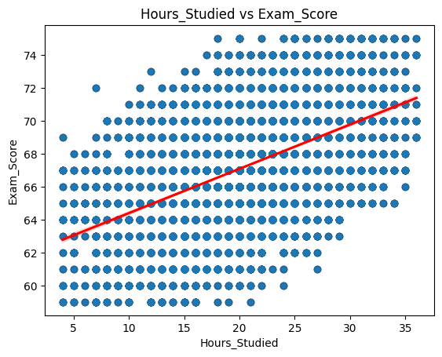

```python
# plotting the relationship between Hours_Studied and Exam_Score
plt.scatter(df['Hours_Studied'], df['Exam_Score'], edgecolor='black')

# regression line
sns.regplot(x='Hours_Studied', y='Exam_Score', data=df, line_kws={'color': 'red'})

# labels
plt.title("Hours_Studied vs Exam_Score")
plt.xlabel("Hours_Studied")
plt.ylabel("Exam_Score")
plt.show()
```

```python
# appling the pearson correlation test and getting the p value
result = stats.pearsonr(df['Hours_Studied'], df['Exam_Score'])
print(f"P-value: {result.pvalue}")
```

```
P-value: 0.0
```

**Hypothesis Test 2: Attendance vs. Exam_Score**

Attendance represents the proportion of classes a student attended. Since both variables are continuous, the best statistical technique for analyzing their relationship is the Pearson correlation test. This test enables us to determine whether a student's academic performance and their degree of class attendance have a significant linear relationship. The alternative hypothesis says that there is a correlation between Exam_Score and Attendance, but the null hypothesis says that there is none. In order to visually check whether students who attend more classes often obtain higher scores in exam, we create a scatter plot with a regression line to support the results of the statistical test. Any patterns found by the correlation test are supported by this graph, which provides further information about the direction and strength of the correlation.

Null Hypothesis: There is no linear relationship between Attendance and Exam_Score.

Alternative Hypothesis: There is a linear relationship between Attendance and Exam_Score.

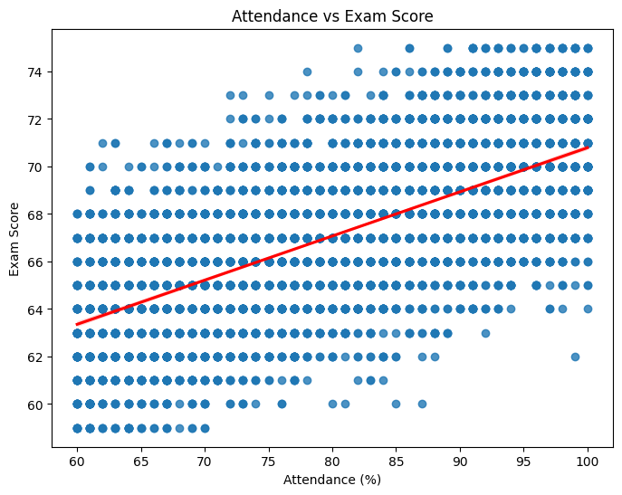

```python
# plotting the relationship between Attendance and Exam_Score
plt.figure(figsize=(8, 6))

# regression line
sns.regplot(x='Attendance', y='Exam_Score', data=df, line_kws={'color': 'red'})

# labels
plt.title('Attendance vs Exam Score')
plt.xlabel('Attendance (%)')
plt.ylabel('Exam Score')
plt.show()
```

```python
# applying the correlation test and getting the p value
result = stats.pearsonr(df['Attendance'], df['Exam_Score'])
print(f"P-value: {result.pvalue}")
```

```
P-value: 0.0
```

The p-value of 0.0, obtained from the Pearson correlation test, provides strong evidence to reject the null hypothesis. In this case, the null hypothesis states that there is no relationship between Attendance and Exam_Score. The extremely small p-value—far below commonly used significance levels such as 0.05 or 0.01—indicates that the observed association is highly unlikely to have occurred by chance. Therefore, we confidently reject the null hypothesis and conclude that there is a statistically significant relationship between class attendance and exam performance. This conclusion is further supported through the plot above which shows how the two variables are having linear relationship.

**Hypothesis Test 3: Access_to_Resources vs. Exam_Score**

Access to Resources is a category variable that indicates the availability of academic resources and support classified as Low, Medium, or High. The Exam Score feature is a continuous variable that measures a student's performance on the final exam. The purpose of this analysis is to determine whether exam results are statistically affected by the degree of access to educational resources. The most suitable approach is a one-way ANOVA, which checks for variations in mean scores between the categories, as we are comparing Exam_Score across three distinct groups. We can determine whether students with varying access levels typically perform differently on their final exam by using this test. We visually examine the differences in exam scores between and within the Low, Medium, and High resource groups using a box plot to support our statistical analysis.

Null Hypothesis:

The mean Exam_Score is the same across all groups of Access_to_Resources.

Alternative Hypothesis:

At least one group's mean Exam_Score is different.

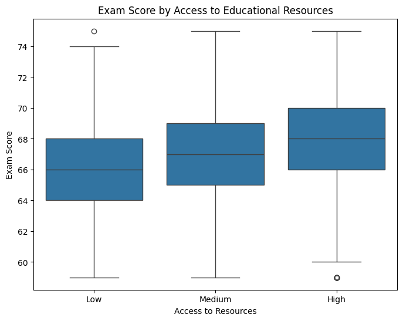

```python
# plotting the relationship between Access_to_Resources and Exam_Score
plt.figure(figsize=(8, 6))

# using the boxplot to represent the relationship
sns.boxplot(x='Access_to_Resources', y='Exam_Score', data=df, order=['Low', 'Medium', 'High'])

# labels
plt.title('Exam Score by Access to Educational Resources')
plt.xlabel('Access to Resources')
plt.ylabel('Exam Score')
plt.show()
```

```python
# splitting the data into 3 parts based on low medium and high access to resources and getting exam scores for each group
low = df[df['Access_to_Resources'] == 'Low']['Exam_Score']
medium = df[df['Access_to_Resources'] == 'Medium']['Exam_Score']
high = df[df['Access_to_Resources'] == 'High']['Exam_Score']

# applying the one_way ANOVA test and getting the p value
f_stat, p_val = f_oneway(low, medium, high)
print(f"F-statistic: {f_stat:.3f}, p-value: {p_val:.4e}")
```

```
F-statistic: 118.824, p-value: 2.0050e-51
```

The one-way ANOVA test resulted in a p-value of 2.0050e-51, which is a very small value, so it indicates a rejection of the null hypothesis. The null hypothesis was that the mean Exam_Score for each of the three Access_to_Resources levels (Low, Medium, and High) was the same. However, the vey low p-value that we got by applying ANOVA test is below our significance level 0.05. This provides significant evidence to reject the null hypothesis and conclude that Exam_Score varies statistically significantly amongst the various resource access groups. More specifically, this indicates that student performance on final exams is significantly influenced by the availability of educational resources. The box plot above illustrates how students with more access to resources typically receive higher scores. So it supports our statistical findings and the conclusion that academic resource availability is a critical component of student achievement.

**Hypothesis Test 4: Tutoring_Sessions vs. Exam_Score**

The Pearson correlation test is used to determine whether there is a statistically significant linear relationship between two continuous variables. We aim to find out if students who attend more tutoring sessions each month do better on their final exams compared to those who do not. According to the null hypothesis, there is no relationship between exam scores and the number of tutoring sessions. However, according to the alternative hypothesis, there is a correlation. In addition, we visually analyze the relationship using a scatter plot with a regression line. This helps to observe if Exam_Score is correlated to the number of Tutoring_Sessions grows.

Null Hypothesis: There is no linear relationship between Tutoring_Sessions and Exam_Score.

Alternative Hypothesis: There is a linear relationship between Tutoring_Sessions and Exam_Score.

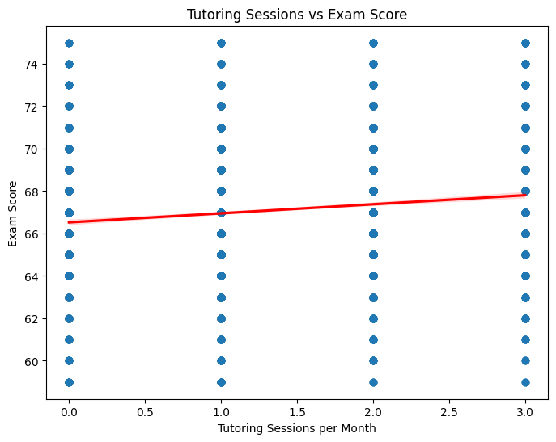

```python
# plotting the relationship between Tutoring_Sessions and Exam_Score
plt.figure(figsize=(8, 6))

# regression line
sns.regplot(x='Tutoring_Sessions', y='Exam_Score', data=df, line_kws={'color': 'red'})

# labels
plt.title('Tutoring Sessions vs Exam Score')
plt.xlabel('Tutoring Sessions per Month')
plt.ylabel('Exam Score')
plt.show()
```

```python
# applying the pearson correlation test and getting the p value
r, p_pearson = pearsonr(df['Tutoring_Sessions'], df['Exam_Score'])
print(f"Pearson r = {r}, p-value = {p_pearson}")
```

```
Pearson r = 0.12629827103024507, p-value = 6.667887399938737e-25
```

According to the correlation test, the null hypothesis was strongly rejected with a p-value of 6.667887399938737e-25. Exam_Score and Tutoring_Sessions do not have a linear connection, according to the null hypothesis in this instance. On the other hand, a p-value this tiny, much below conventional significance levels such as 0.05 or 0.01—indicates that the observed link is very unlikely to have happened by accident. Therefore, we have good reason to reject the null hypothesis and come to the conclusion that a student's performance on the final exam is statistically correlated with the number of tutoring sessions they attend. From a practical standpoint, this suggests that students who attend more tutoring sessions typically score higher on tests. The scatter plot above, which graphically illustrates the positive correlation between Tutoring_Sessions and Exam_Score and shows that greater academic support is linked to better exam results, is included to bolster this conclusion.

**Hypothesis Test 5: Previous_Scores vs. Exam_Score**

Exam Score and Previous Scores are both continuous variables. One shows the student's final exam grade, and the other shows the student's results from prior tests, respectively.Our goal is to determine whether a student's final exam score and their prior academic performance have a significant link. A correlation test, such as the Pearson correlation, which shows both the direction and strength of a linear relationship between two continuous variables, is the most effective way to examine this relationship. We use a scatter plot with a regression line to visually examine this relationship and see if greater prior scores are often associated with higher final exam scores. This plot provides a clear visual representation of the relationship and supports any patterns discovered by the correlation test.

Furthermore, the following are the null and alternative hypotheses:

Null Hypothesis:

There is no linear relationship between Previous_Scores and Exam_Score.

Alternative Hypothesis:

There is a relationship between Previous_Scores and Exam_Score.

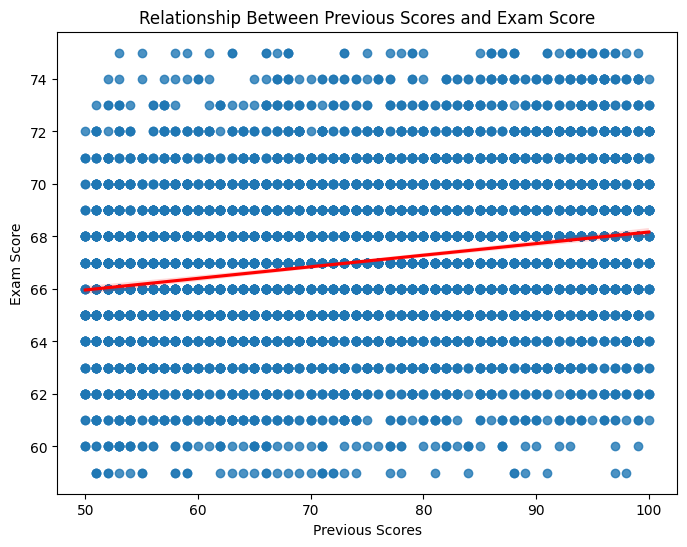

```python
# plotting the relationship between Previous_Scores and Exam_Score
plt.figure(figsize=(8,6))

# regression line
sns.regplot(x='Previous_Scores', y='Exam_Score', data=df, line_kws={'color':'red'})

# labels
plt.title('Relationship Between Previous Scores and Exam Score')
plt.xlabel('Previous Scores')
plt.ylabel('Exam Score')
plt.show()
```

```python
# applying the pearson correlation test and getting the p value
r, p_value = pearsonr(df['Previous_Scores'], df['Exam_Score'])
print(f"Pearson correlation coefficient: {r}, p-value: {p_value}")
```

```
Pearson correlation coefficient: 0.19738020925117933, p-value: 5.015722989558039e-59
```

According to the correlation test, the null hypothesis was strongly rejected with a p-value of 5.015722989558039e-59. Exam_Score and Previous_Scores do not have a linear connection. But a p-value this little, significantly below standard significance thresholds such as 0.05 or 0.01 indicates that There is a relationship between Previous_Scores and Exam_Score. Therefore, we have good reason to reject the null hypothesis and come to the conclusion that a student's performance on the final exam is statistically correlated with the student's Previous_Scores. The scatter plot above, which graphically illustrates the positive correlation between Previous Scores and Exam_Score supports this conclusion.

### Relationship between Behavior Factors and Student Performance

The behavioral factors present in our dataset are Extracurricular Activities, Sleep Hours, Motivation Level, Family Income, and School Type. For our second step, we will examine the relationship between our target variable, which is Exam_Score and behavioral factors. These behavioral factors provide useful information regarding a student's individual behaviors, mental health, and socioenvironmental background. For example:

- Extracurricular Activities: This factor in our dataset is important for students as students gain useful skills from them. However, it takes some of a student's time and energy, so there might be a relationship between a student's performance and extracurricular activities.
- Sleep Hours: Sufficient sleep hours are also important since they are scientifically related to cognitive functionality.
- Motivation Level: A high or low motivation level is significant in our analysis as it is related to the engagement of students in class.
- Family Income: This is a big factor as it plays a role in providing support for students.
- School Type: School type (public vs private) may or may not significantly impact student performance, but it is a factor worth investigating.

Finally, our main goal is to to determine if there is a significant correlation between Exam_Score and various behavioral factors by using the proper statistical tests.

**Hypothesis Test 6: Extracurricular_Activities vs. Exam_Score**

Extracurricular_Activities is a categorical variable since it indicates involvement in extracurricular activities (with values Yes or No). The final grade is represented by the continuous variable Exam_Score. With this framework in place, our goal is to determine if students who engage in extracurricular activities and those who do not perform significantly differently on exams. We may use a variety of plot types to visually evaluate this relationship and help our hypothesis testing (such as an independent samples t-test). This is further enhanced by a violin plot, which displays the complete density distribution and is useful in cases when the data is non-normal or skewed. By offering a visual representation of the potential or actual impact of extracurricular activity engagement on academic achievement, these visualizations enhance the statistical test. In addition the null and alternative hypothesis are as follow:

Null Hypothesis: The mean Exam_Score is equal across all groups (Yes / No) of Extracurricular_Activities.

Alternative Hypothesis: The mean Exam_Score is different across all groups (Yes / No) of Extracurricular_Activities.

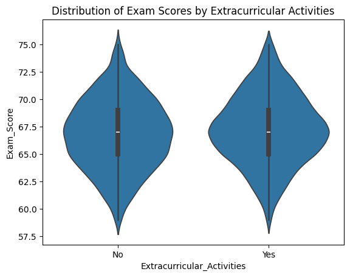

```python
# plotting the relationship between Extracurricular_Activities and Exam_Score
# getting a picture of density of data and how it is distributed
sns.violinplot(x='Extracurricular_Activities', y='Exam_Score', data=df)
plt.title('Distribution of Exam Scores by Extracurricular Activities')
plt.show()
```

```python
# Split Extracurricular_Activities into groups  of yes and no and then getting the exam scores for each group
group_yes = df[df['Extracurricular_Activities'] == 'Yes']['Exam_Score']
group_no = df[df['Extracurricular_Activities'] == 'No']['Exam_Score']

# Performing independent t-test for two samples and getting the p value
t_stat, p_val = ttest_ind(group_yes, group_no, equal_var=False)  # use equal_var=True if variances are equal
print(f"T-statistic: {t_stat:.3f}, p-value: {p_val}")
```

```
T-statistic: 5.344, p-value: 9.463218287002691e-08
```

**Hypothesis Test 7: Sleep_Hours vs. Exam_Score**

Exam_Score is the final exam grade. Sleep_Hours is the average number of hours of sleep a student receives each night. We will examine the link between the two continuous variables using a correlation test. Finding out if there is a statistically significant correlation between academic achievement and sleep duration is the aim of this investigation. According to the null hypothesis, there is no relationship between Exam_Score and Sleep_Hours. However, the alternative hypothesis states that there is a correlation between them. We first visualize the relationship of these variables through plot.

Null Hypothesis: There is no correlation between Sleep_Hours and Exam_Score.

Alternative Hypothesis: There is a significant correlation between Sleep_Hours and Exam_Score.

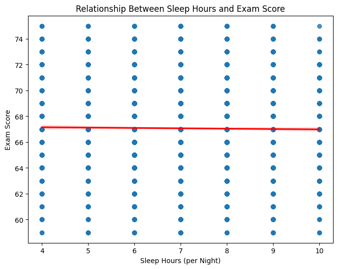

```python
# Scatter plot with regression line
plt.figure(figsize=(8, 6))
sns.regplot(x='Sleep_Hours', y='Exam_Score', data=df, line_kws={'color': 'red'})

# labels
plt.title('Relationship Between Sleep Hours and Exam Score')
plt.xlabel('Sleep Hours (per Night)')
plt.ylabel('Exam Score')
plt.show()
```

```python
# applying the pearson correlation test and getting the p value
r, p = pearsonr(df['Sleep_Hours'], df['Exam_Score'])
print(f"Pearson correlation: r = {r:.3f}, p-value = {p}")
```

```
Pearson correlation: r = -0.012, p-value = 0.31382982247999364
```

The p-value of 0.31382982247999364 does not provide sufficient evidence to reject the null hypothesis. In this case, the null hypothesis states that there is no correlation between Sleep_Hours and Exam_Score. In other words, changes in the amount of sleep a student gets per night are not associated with changes in their exam performance. Since the p-value is greater than the standard significance thresholds like 0.05 or 0.01, we fail to reject the null hypothesis. In conclusion, there is no statistically significant correlation between average sleep duration and exam score. We also visualized the data in the above plot, which shows the distribution of Exam_Scores across different levels of Sleep_Hours. The absence of a clear link between these variables further supports our conclusion.

**Hypothesis Test 8: Motivation_Level vs. Exam_Score**

Motivation_Level shows the student's self-reported level of motivation classified as Low, Medium, or High in our dataset. Given that Exam_Score is continuous and Motivation_Level is a categorical variable with three levels, we implement a one-way ANOVA test to determine whether exam performance has any statistically significant relationship with motivation level of students. The null hypothesis in this case states that there is no difference in mean Exam_Score across the three levels of Motivation_Level. While, the alternative hypothesis suggests that at least one motivation group has a mean Exam_Score that significantly differs from the others. To begin this analysis, we first visualize the relationship between Motivation_Level and Exam_Score using a plot, which allows us to observe the distribution and potential differences in exam scores among the Low, Medium, and High motivation levels.

Null Hypothesis: Mean Exam_Score is the same across all levels of Motivation_Level.

Alternative Hypothesis: At least one group's mean Exam_Score is different.

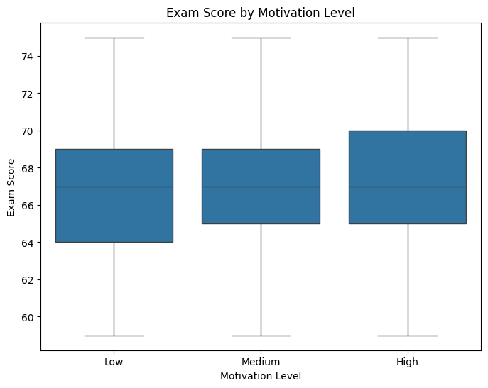

```python
# plotting the relationship between Motivation_Level and Exam_Score
plt.figure(figsize=(8, 6))
sns.boxplot(x='Motivation_Level', y='Exam_Score', data=df, order=['Low', 'Medium', 'High'])

# labels
plt.title('Exam Score by Motivation Level')
plt.xlabel('Motivation Level')
plt.ylabel('Exam Score')
plt.show()
```

```python
# splitting the data of Motivation_Level feature into 3 groups of low medium and high and then getting their exam scores
low = df[df['Motivation_Level'] == 'Low']['Exam_Score']
medium = df[df['Motivation_Level'] == 'Medium']['Exam_Score']
high = df[df['Motivation_Level'] == 'High']['Exam_Score']

# applying the oneway ANOVA test and geting the p value
f_stat, p_val = f_oneway(low, medium, high)
print(f"F-statistic: {f_stat}, p-value: {p_val}")
```

```
F-statistic: 29.674674031652046, p-value: 1.479168332387e-13
```

We reject the null hypothesis based on the one-way ANOVA test's p-value of 1.479168332387e-13. The null hypothesis asserts that the mean Exam_Score is the same for all Motivation_Level groups (Low, Medium, and High). With a p-value that is smaller than the commonly accepted significant thresholds of 0.05 or 0.01, we can reject the null hypothesis and conclude that Motivation_Level and Exam_Score are statistically significantly correlated. The above graphic, which illustrates the distribution of exam scores among students classified as Low, Medium, or High motivation, further illustrates the relationship between Motivation_Level and Exam_Score.

**Hypothesis Test 9: Family_Income vs. Exam_Score**

Family_Income represents the student's socioeconomic background, and it is categorized as Low, Medium, or High. Given that Exam_Score is a continuous variable and Family_Income is a categorical variable with three levels, we again implement a one-way ANOVA test to determine whether there are statistically significant differences in exam performance across the different income groups. The null hypothesis in this case states that there is no difference in the mean Exam_Score across the three income levelswhichsuggest that family income has no effect on exam performance. The alternative hypothesis says that at least one income group has a mean Exam_Score that significantly differs from the others. We first visualize the relationship between Family_Income and Exam_Score through a plot, which allows us to examine how exam scores are distributed among students from Low, Medium, and High income households.

Null Hypothesis: Mean Exam_Score is equal across all Family_Income levels.

Alternative Hypothesis: At least one group's mean Exam_Score is different.

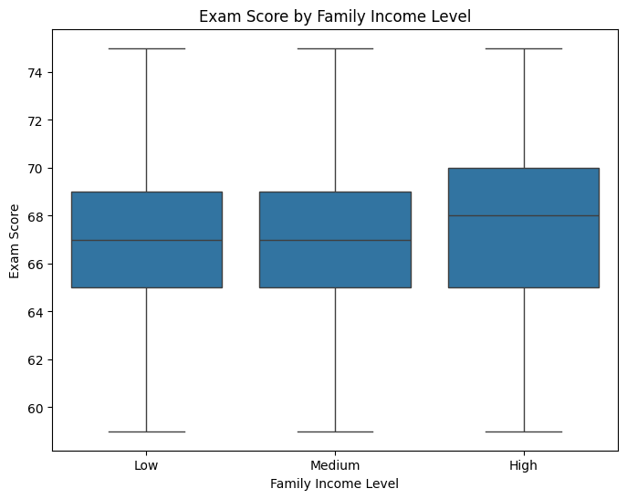

```python
# plotting the relationship between Family_Income and Exam_Score
plt.figure(figsize=(8, 6))
sns.boxplot(x='Family_Income', y='Exam_Score', data=df, order=['Low', 'Medium', 'High'])

# labels
plt.title('Exam Score by Family Income Level')
plt.xlabel('Family Income Level')
plt.ylabel('Exam Score')
plt.show()
```

```python
# splitting the data of Family_Income column into 3 groups of high medium and low and then getting the exam scores for each group
low = df[df['Family_Income'] == 'Low']['Exam_Score']
medium = df[df['Family_Income'] == 'Medium']['Exam_Score']
high = df[df['Family_Income'] == 'High']['Exam_Score']

# applying the oneway ANOVA test and getting the p value
f_stat, p_val = f_oneway(low, medium, high)
print(f"F-statistic: {f_stat}, p-value: {p_val}")
```

```
F-statistic: 29.273278919096438, p-value: 2.2019072384708512e-13
```

The p-value of 2.2019072384708512e-13 from the one-way ANOVA test allows us to safely reject the null hypothesis. In this instance, the null hypothesis states that all Family_Income groups (Low, Medium, and High) have the same mean Exam_Score. Given that the p-value is so small, there is a statistically significant correlation between Exam_Score and Family_Income. To put it another way, students from varying socioeconomic backgrounds typically score differently on their final exams. This association is further demonstrated, and the results of our statistical study are supported by the above graph, which shows the distribution of Exam_Score among students classified by Low, Medium, or High Family_Income.

**Hypothesis Test 10: School_Type vs. Exam_Score**

School_Type feature includes the two sorts of school that students attend, private and public. Exam_Score is a continuous variable in our dataset, while School_Type is a categorical variable. We use an independent samples t-test to see whether the kind of school attended significantly affects exam performance. According to the null hypothesis, students attending public and private schools have the same mean Exam_Score. We reject the null hypothesis and come to the conclusion that there is a correlation between exam performance and school type if the test's p-value is less than the significance level. If it is not that case then we fail to reject the null hypothesis and conclude that the two types of schools do not differ in exam scores. We also use a box plot to show the distribution of Exam_Scores between the two groups.

Null Hypothesis (H₀): Mean Exam_Score is equal across all School_Type groups (Public / Private).

Alternative Hypothesis (H₁): Mean Exam_Score is different across all School_Type groups (Public / Private).

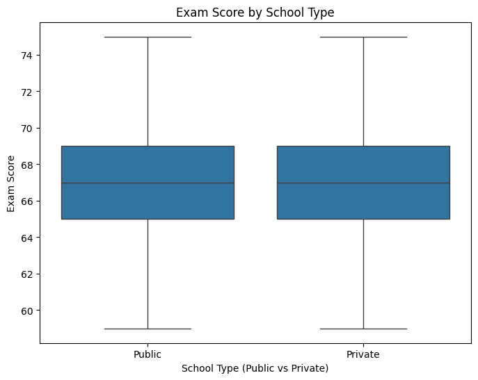

```python
# plotting the relationship between School_Type and Exam_Score
plt.figure(figsize=(8, 6))
sns.boxplot(x='School_Type', y='Exam_Score', data=df)

# lables
plt.title('Exam Score by School Type')
plt.xlabel('School Type (Public vs Private)')
plt.ylabel('Exam Score')
plt.show()
```

```python
# splitting the dataset into two groups (public and private school type) and getting their exam scores
public_exam_scores = df[df['School_Type'] == 'Public']['Exam_Score']
private_exam_scores = df[df['School_Type'] == 'Private']['Exam_Score']

# using independent t test for two samples and getting the p value
t_stat, p_val = ttest_ind(public_exam_scores, private_exam_scores, equal_var=False)
print(f"T-statistic: {t_stat}, p-value: {p_val}")
```

```
T-statistic: -1.0180685598536012, p-value: 0.30870936323555076
```

The independent samples t-test yielded a p-value of 0.30870936323555076, which suggests that there is not enough data to draw the conclusion that students from public and private schools perform significantly differently on exams. The null hypothesis in this case is that the average Exam_Score is the same for all types of schools. Therefore, we conclude that School_Type is not statistically related to a difference in Exam_Score and do not reject the null hypothesis. We used a box plot to show the data in order to investigate the relationship further. The distribution of test scores among students from public and private schools is shown in the plot.

## **Primary analysis**

After completing the exploratory data analysis section, based on findings from the hypothesis testing, the best choice for our machine learning is supervised linear regression model. Our goal is to predict student’s Exam_Score using combination of behavioral and academic features. It is supervised because we have historical data that includes labels for the target variable of Exam_Score. Since the target variable is continues, we must use regression model instead of other models such as classification. In addition to predicting the values regression helps us to see strength and direction of each feature on target variable. Therefore, the question that we aim to solve which is to see what factors influence the most student performance and how to predict the score of a student is solved through this model. Below we have implemented the regression model for the data and applied it.

```python
# dropping the columns that did not have any relationship according to the hypothesis testing
# since they will not provide any insights if used in the model
df = df.drop(columns=['Sleep_Hours', 'School_Type'])

# encoding the catagorical data columns since machine learning will not perform will with catagorical data
df_encoded = pd.get_dummies(df, drop_first=True)

# assining our features and target variable data into X Y repectively
X = df_encoded.drop(columns=['Exam_Score'])
Y = df_encoded['Exam_Score']


# splitting our train and test datasets for both features and target variables
X_train, X_test, Y_train, Y_test = train_test_split(X, Y, test_size=0.2, random_state=42)


# standardizing our data for better performance in linear regression
scaler = StandardScaler()
X_train_scaled = scaler.fit_transform(X_train)
X_test_scaled = scaler.transform(X_test)


# creating the model
model = LinearRegression()

# fitting the model on our training features and target variable
model.fit(X_train_scaled, Y_train)

# predicting the outcome of test data
Y_pred = model.predict(X_test_scaled)

# calculating the mean squared error in regard to actual and predicted outcome
mse = mean_squared_error(Y_test, Y_pred)

# Calculating R^2
r2 = r2_score(Y_test, Y_pred)

# displaying the results of mean squared error and R^2
print(f"Mean Squared Error: {mse:.2f}")
print(f"R² Score: {r2:.3f}")
```

```
Mean Squared Error: 1.99
R² Score: 0.811
```

## **Visualization**

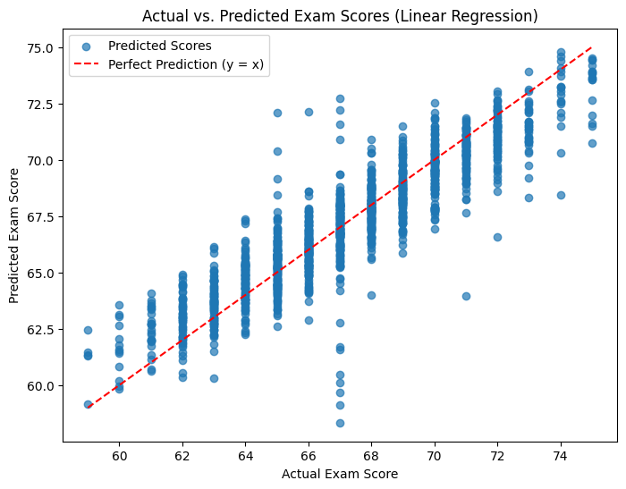

```python
# plotting the result of machine model (actual vs predicted outcomes)
plt.figure(figsize=(8,6))
plt.scatter(Y_test, Y_pred, alpha=0.7, label='Predicted Scores')
plt.plot([Y_test.min(), Y_test.max()], [Y_test.min(), Y_test.max()], 'r--', label='Perfect Prediction (y = x)')

# lebels
plt.xlabel('Actual Exam Score')
plt.ylabel('Predicted Exam Score')
plt.title('Actual vs. Predicted Exam Scores (Linear Regression)')

# the legend
plt.legend()
plt.show()
```

## **Insights and Conclusions**

The aim of this project was to investigate which academic and behavioral factor influence student performance and can we create a model that can predict the student exam suing those combination of academic and behavioral factors. we have discovered very important conclusions using statistical testing, exploratory data analysis, and machine learning model that was built based on linear regression.

**Key Findings:**

The concept that socioenvironmental factors significantly influence learning outcomes was supported by the one-way ANOVA testing, which showed that categorical variables like Motivation_Level, Family_Income, and Access_to_Resources also significantly affect academic achievement.

**Model Performance:**

All those features that had a strong relationship with the target variable were used to train the model. It achieved a very low mean squared error of 1.99 and a high R^2 value of 0.811. The value of R^2 implies that 81.1% of the variance can be correctly predicted using the input features. It shows a strong prediction accuracy. To further support these findings, we added a plot of actual data vs. the predicted ones.

**Conclusion:**

By questioning presumptions and highlighting evidence, this project provides an uninformed reader with a clear, data-driven understanding of which factors actually affect student achievement. For a more seasoned reader, the application of feature encoding methods, statistical rigor, and model evaluation offers significant insights into the predictive power of behavioral and educational variables.

By pointing out areas where intervention may be most successful—specifically, in improving access to tutoring, promoting consistent study habits, and tackling socioeconomic and motivational barriers—the findings can help educators, legislators, and academic support programs.